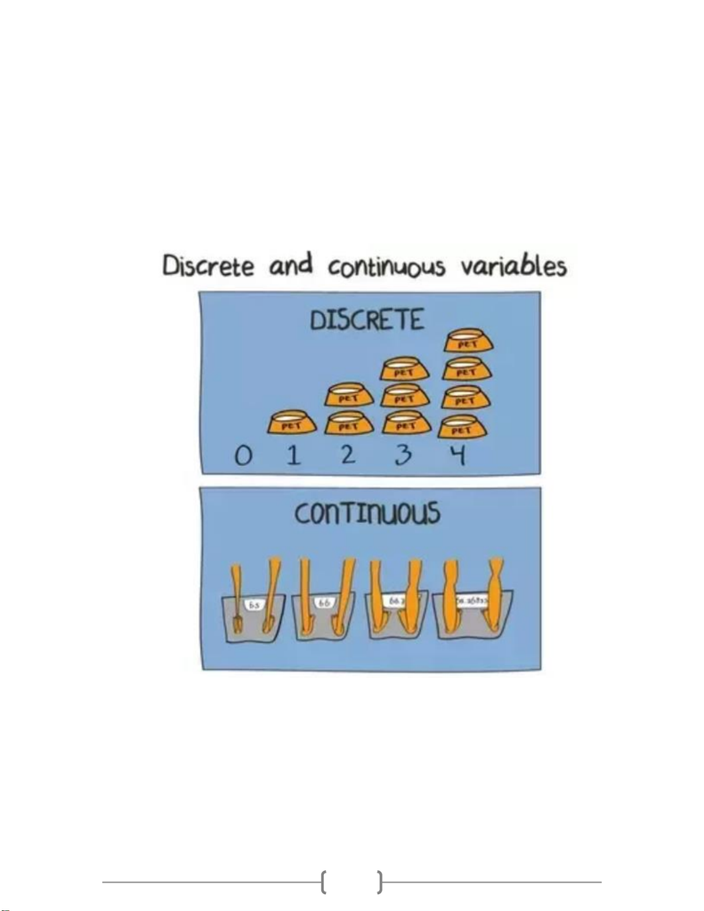

1

Ejercicios sugeridos sobre variables aleatorias

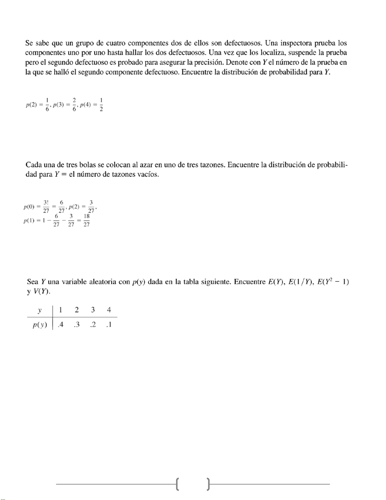

2

Ejercicio 3.3 de Wackerly (2010)

Rta:

Ejercicio 3.7 de Wackerly (2010)

Rta:

Ejercicio 3.12 de Wackerly (2010)

Rta:

Por hacer.

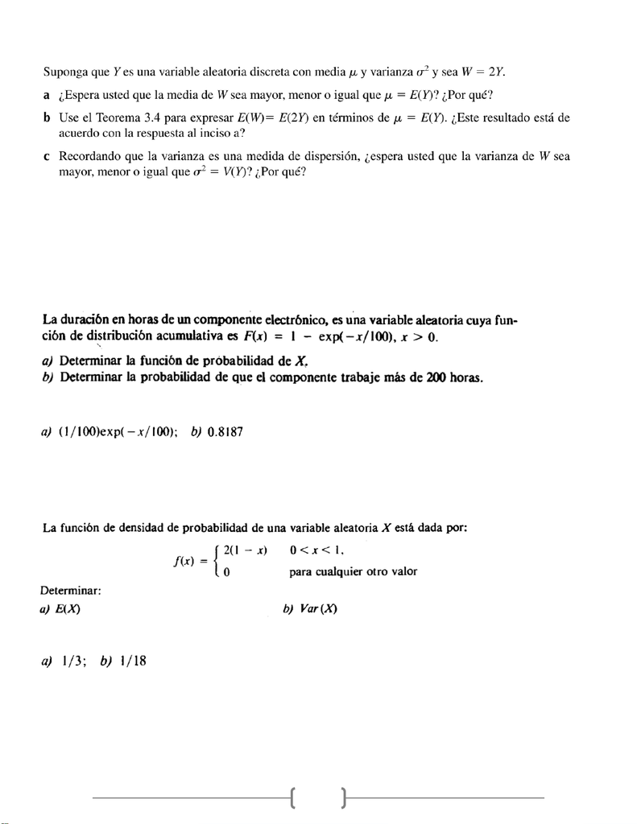

3

Ejercicio 3.31 de Wackerly (2010)

Rta:

Por hacer.

Ejercicio 3.5 de Canavos (1988)

Rta:

Ejercicio 3.9 de Canavos (1988)

Rta:

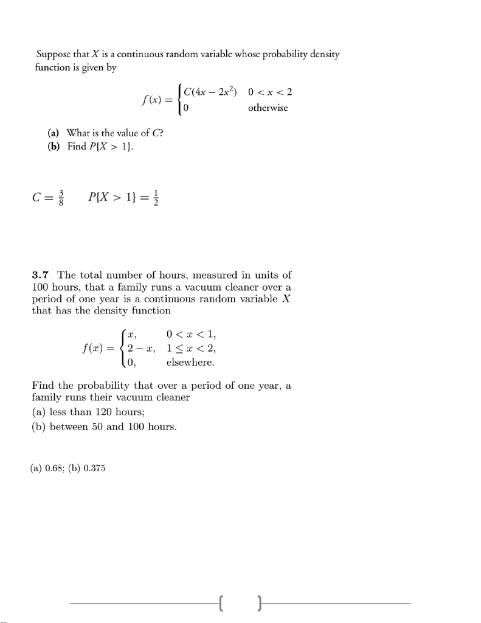

4

Ejemplo 4.2b de Ross (2014)

Rta:

Ejercicio 3.7 de Walpole (2012)

Rta:

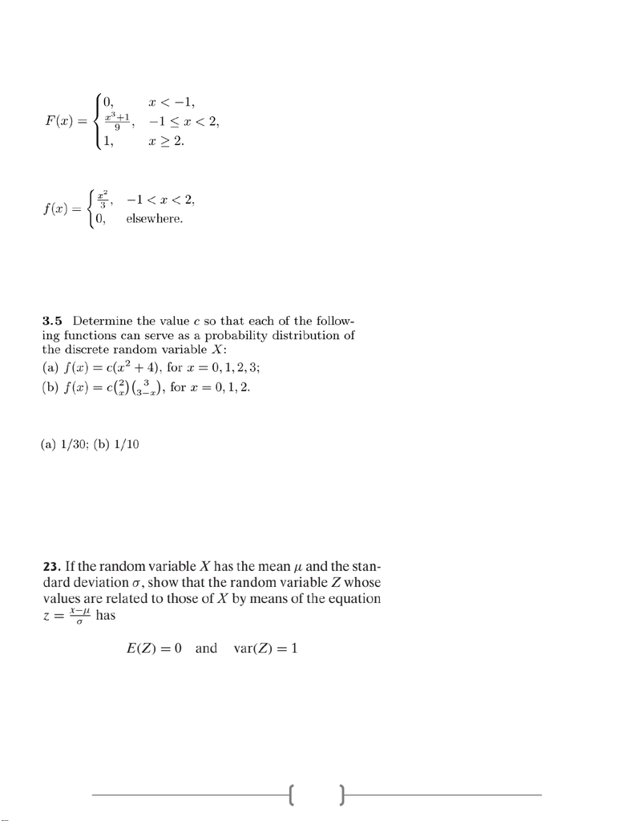

5

Ejemplo 3.12 de Walpole (2012)

Abajo está la fórmula de una función acumulada, encontrar la función de densidad a partir de ella.

Rta:

Ejercicio 3.5 de Walpole (2012)

Rta:

Ejercicio 23 de Freund et. Al (2014)

Rta:

Aplicando las propiedades del valor esperado y la varianza se obtienen las respuestas.

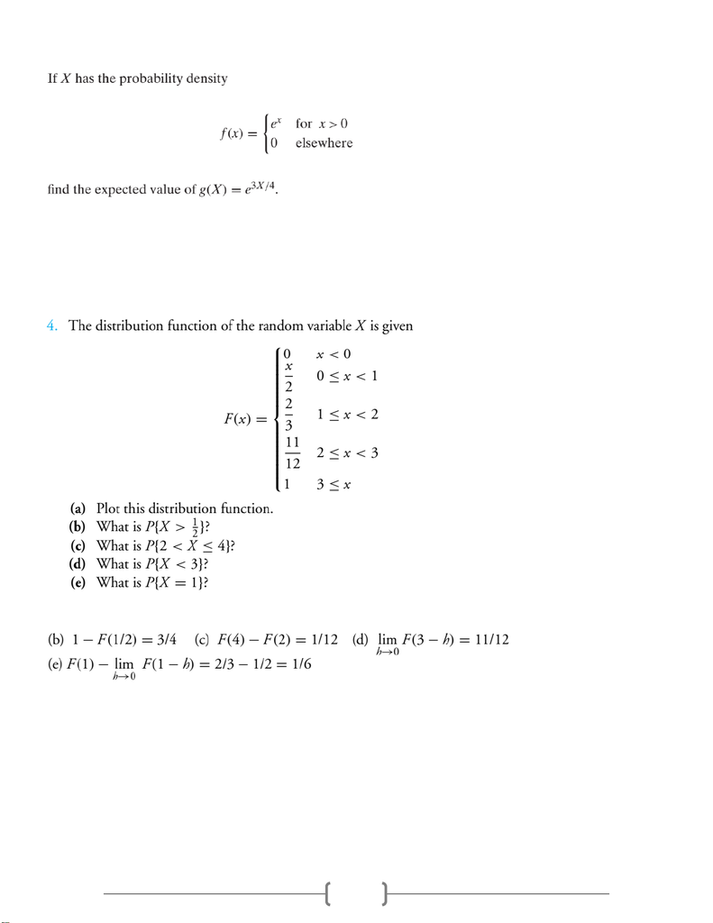

6

Ejemplo 4 de Freund et. Al (2014)

Rta: 4.

Ejercicio 4.4 de Ross (2014)

Rta:

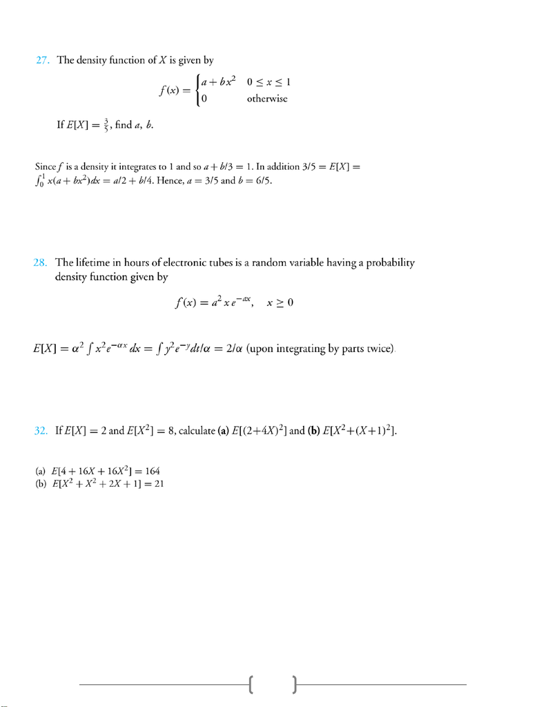

7

Ejercicio 4.27 de Ross (2014)

Rta:

Ejercicio 4.28 de Ross (2014)

Rta:

Ejercicio 4.32 de Ross (2014)

Rta:

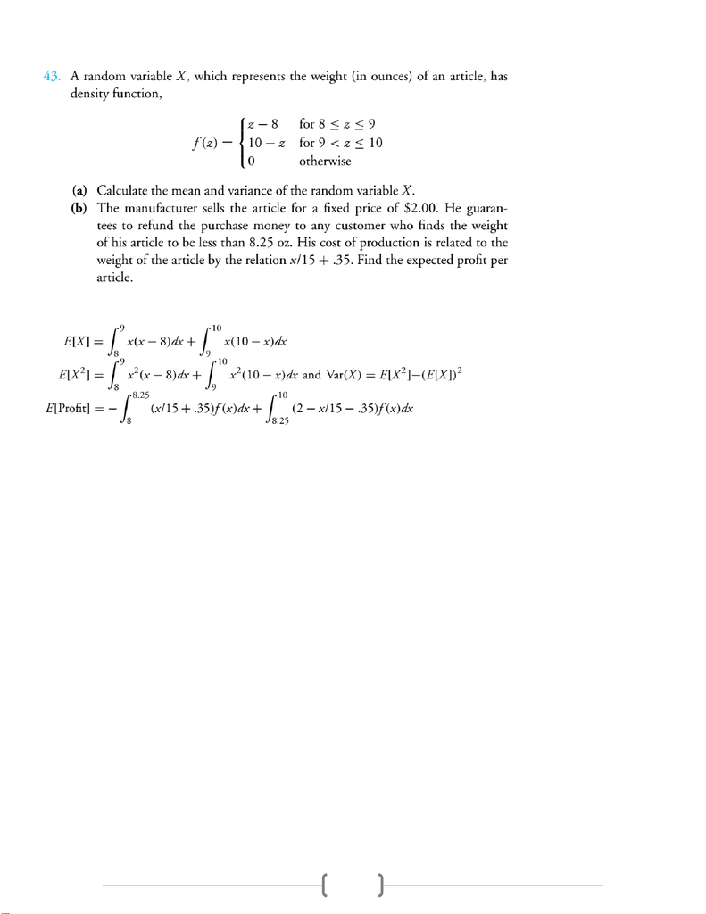

8

Ejercicio 4.43 de Ross (2014)

Rta:

probabilidad de este experimento.

Rta:

Generalizando lo anterior nos permite escribir la función de masa de probabilidad así:

[figure not shown]

9

Se tiene una cartera con cuatro monedas de 500$ y con cinco monedas de 1000$. Se sacan al azar tres

monedas de la cartera, sea X la variable aleatoria número de monedas de 500$ que se sacan. Escriba la

función de masa de probabilidad de este experimento.

Rta: